# Simulating epidemics with the toyepidemic R-package

Venelin Mitov

2017-12-11

# Designing the epidemic

## Define the pathogen genotypes

We set the numbers of different alleles for each quantitative trait locus (QTL) in the pathogen genotype. These are specified in the form of a integer vector with elements bigger or equal to 2. The length of this vector corresponds to the number of QTLs.

```r
library(toyepidemic)
# numbers of alleles for each quantitative trait locus
numsAllelesAtSites <- c(3, 2)

# Define a matrix of the possible genotype encodings (as allele contents).
genotypes <- generateGenotypes(numsAllelesAtSites)
print(genotypes)
```

```
##      [,1] [,2]
## [1,]    1    1
## [2,]    1    2
## [3,]    2    1
## [4,]    2    2
## [5,]    3    1
## [6,]    3    2
```

```r
# Define the probability of the first infecting strain (the first pathogen strain starting the epidemic)
pg.init <- rep(0, nrow(genotypes))
pg.init[1] <- 1 # we specify that 1 is the first strain with probability 1.
```

## Define the number and the frequencies of host-types

```r
# number of host-types
n <- 6

# probability of each host type in a susceptible compartment
pe <- runif(n)
pe <- pe/sum(pe) # ensure that they sum-up to 1
```

## Define the GE-values

The GE-values represent the general genotype x host-type effects. A genotype x host-type effect is the mean trait value of an individual of a given host-type carrying a given pathogen strain in the absence of selection.

```r
# General host-type x strain effects (expected phenotypes for genotype by environment combinations)
GEVs <- matrix(NA, nrow=n, ncol=nrow(genotypes))

# assign random values to each genotype x host-type combination:
for(g in 1:nrow(genotypes)) {
  GEVs[, g] <- rnorm(n=n, mean=2+2/nrow(genotypes)*(g), sd=0.4)
}
```

To get a visual idea of the different GE-values, we can plot them in the form of an R-matplot:

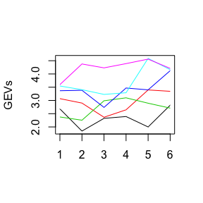

```r
matplot(GEVs, type='l', lty=1, col=1:6)
```

## Define the host-specific effects distribution

The final phenotype of every infected host is the sum of the GE-value for its currently infecting strain and a random host-specific effect. The toyepidemic package assumes that the host-specific effect is a normally distributed random variable drawn exactly once for each possible infecting strain in a newly infected host. This normal distribution has mean 0 and standard deviation defined by the following parameter $\sigma_e$:

```r
# is the special environmental effect unique for each pathogen genoetype in an individual
eUniqForEachG <- TRUE

sigmae <- .6
# it is possible to specify different standard deviations for the different host-types, i.e. different host-types exhibit stronger or weaker effect on the trait. For this example we keep them fixed for all host-types.
sde <- rep(sigmae, n)
```

## Defining the population parameters

At the between-host level we start by defining the size, the birth- and the natural death rate in the population at equilibrium. These are constants:

```r
#initial population size (equilibrium in the absence of disease)
N <- 1e5

# setting the between-host and within-host dynamics of the simulation:
# natural death rate
mu <- 1/850

# constant birth rate that maintains this equilibrium
nu <- ifelse(is.finite(N), mu*N, 0)
```

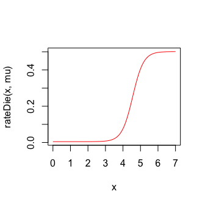

```r
# death-rate as a function of viral load and natural death rate mu
rateDie <- function(z, mu) {
  V <- 10^z
  Dmin <- 2
  Dmax <- 25*12
  D50 <- 10^3
  Dk <- 1.4
  (V^Dk+D50^Dk)/(Dmin*(V^Dk+D50^Dk)+((Dmax-Dmin)*D50^Dk)) + mu
}

curve(rateDie(x, mu), 0, 7, col="red")
```

### Transmission-rate as a function of viral load and rate of risky contacts with susceptible hosts

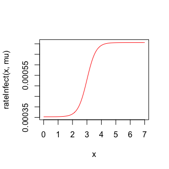

```r
rateContact <- 1/6

# note that at runtime, rateInfect is scaled by the proportion of susceptible hosts
rateInfect <- function(z, rateContact) {
  V <- 10^z
  Emin <- .3
  Emax <- .6
  E50 <- 10^3
  Ek <- 1.4
  E <- Emin+(Emax-Emin)*V^Ek/(V^Ek+E50^Ek)
  E*rateContact
}

curve(rateInfect(x, mu), 0, 7, col="red")
```

### Within-host strain mutation rate

We define a function `rateMutate` which calculates the within-host per-locus mutation rate for a number K of infected hosts. The function recieves the GEVs matrix as an argument and 3 vectors of length K as follows:

- es: numeric : values of currently active host-specific effects;
- envs: integer : host types for the K infected hosts;
- genes: integer : currently infecting strains for the K hosts.

In addition, we specify the mode of within-host evolution (in this case - selection)

```r
# per locus mutation rates
rateMutate <- function(GEValues, es, envs, genes) {
  z <- GEValues[cbind(envs, genes)] + es
  V <- 10^z
  Mmin <- 0.00
  Mmax <- 0.2
  M50 <- 10^3
  Mk <- 1.4
  Mmin+(Mmax-Mmin)*V^Mk/(V^Mk+M50^Mk)
}

# are only beneficial (i.e. increasing the trait-value) mutations allowed
selectWithinHost <- TRUE
```

### Sampling rate for infected host

The event of sampling represents diagnosis and immediate treatment and lifelong immunity and un-infectiousness for the host. For this example, we define a constant sampling rate, independent of the phenotype.

```r
rateSample <- 1/(4*12)
```

## Define the time step and the duration of the simulation

```r
# all events are sampled with this time-step. This means that only one event can happen for an infected host within every next interval of 0.05 (arbitrary time units).
timeStep <- 0.05

# maximum time before starting graceful fadeout of the epidemic
maxTime <- 120

# continue the epidemic outbreak until reaching ...
maxNTips <- 200


# time to continue the simulation of transmission after reaching maxNTips (this was introduced
# in order to study post-outbreak dynamics, i.e. epidemic waves after exhaustion of the
# susceptible pool)
expandTimeAfterMaxNTips <- 0
```

# Running the simulation

To run the simulation we use the function simulateEpidemic with the parameters specified as above:

```r
epidemic <- simulateEpidemic(
  Ninit=N, nu=nu, mu=mu, pe=pe, sde=sde, pg.init=pg.init, GEValues=GEVs,
  rateContact=1/6, rateInfect=rateInfect, rateDie=rateDie,
  rateSample=rateSample,
  rateMutate=rateMutate,
  numsAllelesAtSites=numsAllelesAtSites, eUniqForEachG=eUniqForEachG,
  selectWithinHost=TRUE,
  timeStep=timeStep, maxTime=maxTime, maxNTips=maxNTips,
  expandTimeAfterMaxNTips=expandTimeAfterMaxNTips,
  process="select/select")
```

# Analysing the epidemic

## Extracting the transmission tree connecting sampled host

```r
tree <- extractTree(epidemic)
```

```
## Generating tree: nTips= 200 , number of uncollapsed edges= 686
```

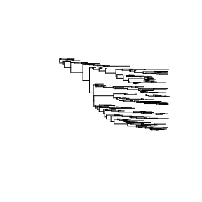

```r
plot(ape::ladderize(tree), show.tip.label = FALSE)
```

## Extract the population of sampled patients

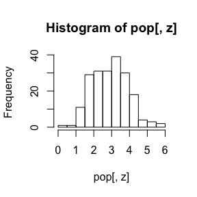

```r
# extract the population of all sampled individuals
pop <- extractPop(epidemic, ids = tree$tip.label)

# calculate their phenotypic values at the moment of diagnosis
pop[, z:=calcValue(env, gene, e, GEValues = epidemic$GEValues)]

hist(pop[, z])
```

## Extract donor-recipient couples

```r
drc1 <- extractDRCouples(epidemic)
```